# demand_forecast

Esad Demirel

PAKETLERİ YÜKLEME

VERİ OKUTMA

(Müşteri no, Satış tarihi, Ürün no, Satış adedi, Sipariş no ve Satış tarihinin hangi yıl-ay içinde yapıldığını gösteren bir verimiz var. Biz daha çok Zaman Serisi Analizi üzerinden tarihleri ve bağlı satış adetlerini inceleyeceğiz.)

```r
tt <- read.csv("taleptahmin.csv")
head(tt)
```

```
##   Customer.Account  SalesDate Product.Number Sales.Quantity Order.number
## 1        Cust00001 2014-01-06        PRD0001           2600    Order0001
## 2        Cust00001 2014-01-06        PRD0002            200    Order0001
## 3        Cust00001 2014-01-06        PRD0003            800    Order0001
## 4        Cust00001 2014-01-06        PRD0004            800    Order0001
## 5        Cust00002 2014-03-05        PRD0003           2400    Order0002
## 6        Cust00002 2014-03-05        PRD0002            600    Order0002
##    Period
## 1 2014-01
## 2 2014-01
## 3 2014-01
## 4 2014-01
## 5 2014-03
## 6 2014-03
```

```r
nrow(tt) # satir kontrolu
```

```
## [1] 156631
```

```r
str(tt)
```

```
## 'data.frame':    156631 obs. of  6 variables:
##  $ Customer.Account: chr  "Cust00001" "Cust00001" "Cust00001" "Cust00001" ...
##  $ SalesDate       : chr  "2014-01-06" "2014-01-06" "2014-01-06" "2014-01-06" ...
##  $ Product.Number  : chr  "PRD0001" "PRD0002" "PRD0003" "PRD0004" ...
##  $ Sales.Quantity  : num  2600 200 800 800 2400 600 800 1050 600 1200 ...
##  $ Order.number    : chr  "Order0001" "Order0001" "Order0001" "Order0001" ...
##  $ Period          : chr  "2014-01" "2014-01" "2014-01" "2014-01" ...
```

```r
class(tt)
```

```
## [1] "data.frame"
```

```r
names(tt)
```

```
## [1] "Customer.Account" "SalesDate"        "Product.Number"   "Sales.Quantity"
## [5] "Order.number"     "Period"
```

```r
summary(tt)
```

```
##  Customer.Account    SalesDate         Product.Number     Sales.Quantity
##  Length:156631      Length:156631      Length:156631      Min.   :-30000.0
##  Class :character   Class :character   Class :character   1st Qu.:    30.0
##  Mode  :character   Mode  :character   Mode  :character   Median :    99.0
##                                                           Mean   :   507.9
##                                                           3rd Qu.:   240.0
##                                                           Max.   : 99000.0
##  Order.number          Period
##  Length:156631      Length:156631
##  Class :character   Class :character
##  Mode  :character   Mode  :character
##
##
##
```

DEĞİŞKEN İSİMLERİNİ DÜZENLEME

```r
names(tt) <- c("CustomerAccount", "SalesDate", "ProductNumber", "SalesQuantity", "OrderNumber", "Period")
names(tt)
```

```
## [1] "CustomerAccount" "SalesDate"       "ProductNumber"   "SalesQuantity"
## [5] "OrderNumber"     "Period"
```

TARİH DEĞİŞKENİNE DATE YAPMA

(Excelden alinan veride kolon genel olarak kaydedilmiştir. Üzerinde tarih işlemleri yapabilmek için as.Date ile tipini düzeltiyoruz.)

```r
tt$SalesDate <- as.Date(tt$SalesDate)
str(tt$SalesDate)
```

```
##  Date[1:156631], format: "2014-01-06" "2014-01-06" "2014-01-06" "2014-01-06" "2014-03-05" ...
```

HİSTOGRAM GRAFİĞİ

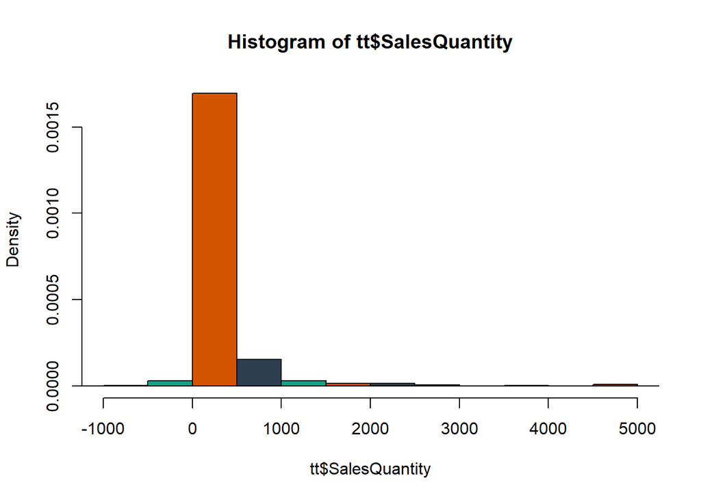

```r
hist(tt$SalesQuantity,
     breaks = 200,
     xlim = c(-1000,5000),
     col = c("#d35400" , "#2c3e50" , "#16a085"), #flatuicolors.com dan renk aldik
     prob = T)
```

ÜRÜN NUMARALARINA GÖRE SATIŞ ADETLERİ

(Bir ürün üzerinden tahmin yapacağız. En fazla veri satırına sahip veriyi bulmak için table() kullanıyoruz. )

```r
toplam <- tt %>%
  group_by(ProductNumber)%>%
  summarize(Toplam_Satis = sum(SalesQuantity))
head(toplam)
```

```
## # A tibble: 6 x 2
##   ProductNumber Toplam_Satis
##   <chr>                <dbl>
## 1 PRA0134            326525.
## 2 PRA0135            675470.
## 3 PRA0136            165971.
## 4 PRA0137            590569.
## 5 PRA0138           2660543.
## 6 PRA0139            516135.
```

```r
table(tt$ProductNumber)
```

```
##
## PRA0134 PRA0135 PRA0136 PRA0137 PRA0138 PRA0139 PRA0140 PRA0141 PRA0142 PRA0143
##     234    1324     453     912    2455     899    1303    2144     806    1478
## PRA0144 PRA0145 PRA0146 PRA0147 PRA0148 PRA0149 PRA0150 PRA0151 PRA0152 PRA0153
##     118     384    1482      67     186     308      81     168     329      39
## PRA0154 PRA0155 PRA0156 PRD0001 PRD0002 PRD0003 PRD0004 PRD0005 PRD0006 PRD0007
##      45     529      85    5974    6465    6670    1357      66     594    2325
## PRD0008 PRD0009 PRD0010 PRD0011 PRD0012 PRD0013 PRD0014 PRD0015 PRD0016 PRD0017
##    4894    2491    2047     932    1498    2007     862     762     573     364
## PRD0018 PRD0019 PRD0020 PRD0021 PRD0022 PRD0023 PRD0024 PRD0025 PRD0026 PRD0027
##     339    2386     411   11114    4894    2496    4027    2524    1357    1612
## PRD0028 PRD0029 PRD0030 PRD0031 PRD0032 PRD0033 PRD0034 PRD0035 PRD0036 PRD0037
##    1066     346     165     748      16    1320    1546      83     645    2363
## PRD0038 PRD0039 PRD0040 PRD0041 PRD0042 PRD0043 PRD0044 PRD0045 PRD0046 PRD0047
##     885    1794    2298    1050    1124    1603     527      69    1229     552
## PRD0048 PRD0049 PRD0050 PRD0051 PRD0052 PRD0053 PRD0054 PRD0055 PRD0056 PRD0057
##     717    1634    3179    2211     188      43      90     314    1246      68
## PRD0058 PRD0059 PRD0060 PRD0061 PRD0062 PRD0063 PRD0064 PRD0065 PRD0066 PRD0067
##     319     685      49      56    1515     273    1075     191     373     914
## PRD0068 PRD0069 PRD0070 PRD0071 PRD0072 PRD0073 PRD0074 PRD0075 PRD0076 PRD0077
##     170     477     462     285     642     851    3321    1161      15     143
## PRD0078 PRD0079 PRD0080 PRD0081 PRD0082 PRD0083 PRD0084 PRD0085 PRD0086 PRD0087
##     409     851     345     609    2328    1407      36     182     139     705
## PRD0088 PRD0089 PRD0090 PRD0091 PRD0092 PRD0093 PRD0094 PRD0095 PRD0096 PRD0097
##     646    1168      93     576    1069     936     393      93     171      84
## PRD0098 PRD0099 PRD0100 PRD0101 PRD0102 PRD0103 PRD0104 PRD0105 PRD0106 PRD0107
##     231    1847     420     730     105     291     181     757    1497    1134
## PRD0108 PRD0109 PRD0110 PRD0111 PRD0112 PRD0113 PRD0114 PRD0115 PRD0116 PRD0117
##     880    1065    1361      72       6      56     335     473     304    1250
## PRD0118 PRD0119 PRD0120 PRD0121 PRD0122 PRD0123 PRD0124 PRD0125 PRD0126 PRD0127
##      90     479      93      31       6      96      31     198     486       4
## PRD0128 PRD0129 PRD0130 PRD0131 PRD0132 PRD0133
##     181     135       3     541      55       1
```

NEGATİF VERİ KONTROLÜ

(Satış adedi negatif olamayacağı için bu verileri giriş hatası olarak kabul ederek verisetinden çıkarıyoruz.)

```r
tt2 <- tt %>%
  filter(SalesQuantity >= 0 , na.rm = TRUE)
```

```r
nrow(tt2)  #153688 satir veri
```

```
## [1] 153688
```

```r
tt_negatif <- tt %>%
  filter(SalesQuantity < 0 , na.rm = TRUE)
nrow(tt_negatif)  #2943 satir veri
```

```
## [1] 2943
```

AYKIRI DEĞER KONTROLÜ

(Veri setimizde şirketin normalde gerçekleştirmediği çok uçuk satış adetleri girilmiştir. Kullanıcı hatası olabilir. Tahminleme modeli üzerine çalıştığımız için daha yakın, gerçekçi verilerle çalışmamız gerekir. Bizi yanıltabilecek verileri ayıklamalıyız. Bunun için iki yöntemi inceliyoruz.)